# Patterns 10 days later

May 17, 2020

The dots are the smoothed (7-day average) of new cases. If plot has a model fit, then the model was fit to the blue dots. The deaths are estimated as CFR (estimated based on 7-day lag) times estimated number of positives (from curve fitting a log-normal). The actual deaths are used for the time up to the current date and on to this are added the expected deaths from the last 7-days of new positives (actual numbers) plus expected future deaths (from forecasted number of new positives.

This is an update to my regional patterns post 10 days ago: https://eeholmes.github.io/CoV19/updates/2020-05-04-Patterns.html

# Europe

Pattern hasn’t really changed in the last two weeks. Most of Europe had an effective lockdown and the epidemic curves look like there will be low rates by early June. Most countries should be below 1 death per million per day by June, and a few countries are well below that or never reached that level at all: Germany, Switzerland, Austria, Norway, all of Eastern Europe. The death rates per million vary from 1900-600 for countries that took a slower pace of lockdown to under 100 deaths per million for countries that locked down early and stopped transmission effectively.

The big exceptions are Sweden and UK. Sweden did a soft lockdown and while its deaths never spiked, they steady at an average of ca 6 per million per day. They are now at 6th highest deaths per million and Europe and should pass France in another week. My projections put them at the top of that list by Sept 1, but that’s a long ways away. The UK delayed their lockdown and deaths per million are also up around 6 (like Sweden) but dropping fast. They are relaxing their lockdown a bit earlier (in terms of deaths per million per day and new cases per million per day) than other European countries.

The CFRs (case fatality rates) across western Europe are 12-20% with lower rates in central and eastern Europe (3-5%). Portugal is a bit of an exception with a CFR of 4.5% versus Spain which is 12.3%. These differences could be caused by different testing strategies, and that’s certainly true for Germany which had high testing levels (tested more people who were not very sick). Most other countries focused on testing people who showed up at hospitals (so quite sick). There is also speculation that the BCG tuberculosis vaccine might be causing some of the differences in spread and CFR in European countries. The BCG vaccine is known to confer protection against repiratory infections and the TB vaccine is part of the normal vaccinnation schedule across eastern Europe and Portugal, but not Spain and not Italy. https://www.thelancet.com/journals/lancet/article/PIIS0140-6736(20)31025-4/fulltext https://www.the-scientist.com/news-opinion/an-old-tb-vaccine-finds-new-life-in-coronavirus-trials-67504 https://www.euronews.com/2020/04/06/has-the-key-to-a-coronoavirus-vaccine-been-staring-us-in-the-face-for-a-century

## Regions and countries with high spread and lockdown

Death rates 1900 to 600 per million people. Lockdown after widespread spread or lockdown insufficient.

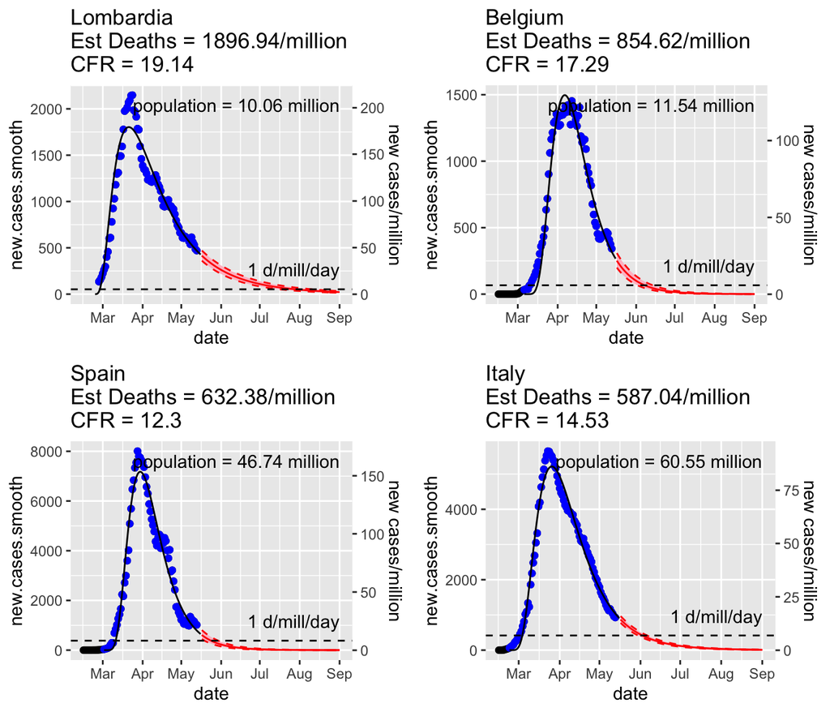

## Regions with intermediate levels of infection

These are cases where new cases/million went over 50-100, but lockdown was effective and stopped the rise and lowered infection rate. Death rate 500 to 150 per million.

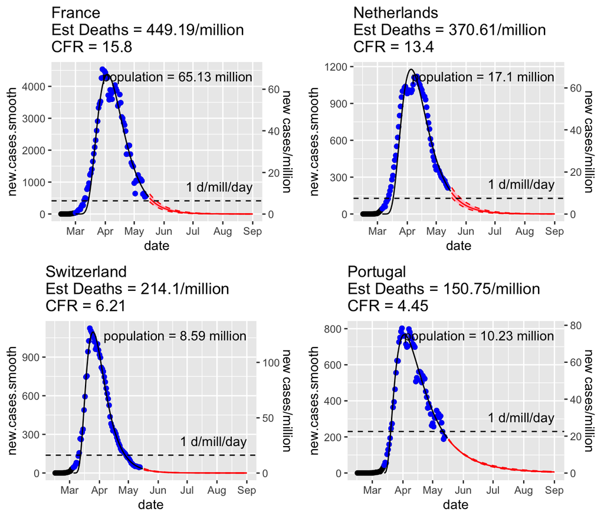

## Regions with very early lockdown. Low spread.

Death rate below 100 per million.

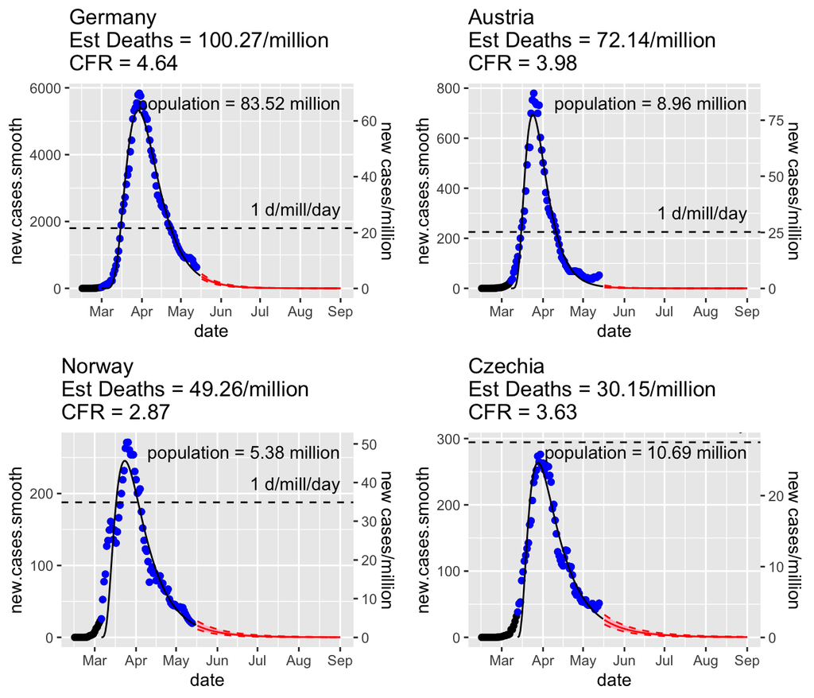

## Sweden and the UK

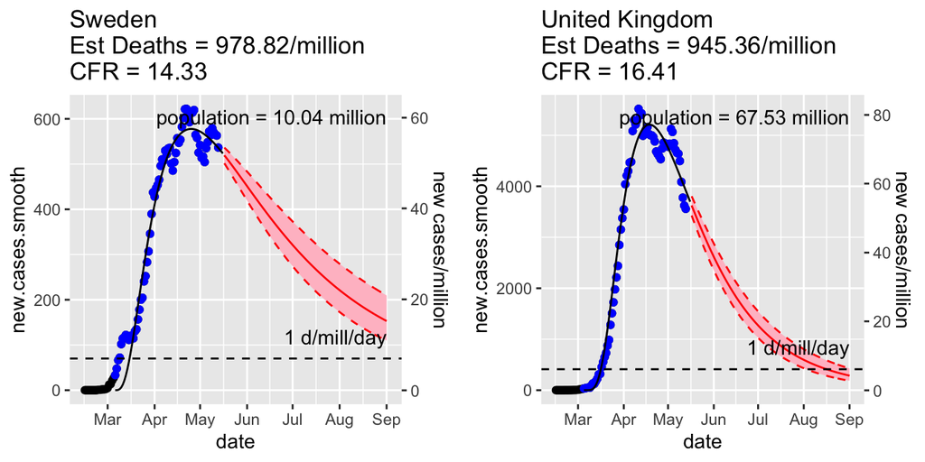

# United States

10 days ago, there was no sign of the peak. Most regions were still going up. 10 days later, most regions show a peak. Currently only the western south region (TX+OK+KS+AR). The CFR in that region is quite low (3.56%) suggesting that most of these infections are in the meat processing industry. There is a regional outbreak in north TX and southwest KS in the plants. These are younger people, so less mortality, and there is more testing of people with less severe symptoms (so not as sick). In other regions, the outbreaks associated with meat processing have peaked in 2-4 weeks, so I would expect that we’ll see the same in TX.

CFRs across the US are lower than in Europe. 3.5 to 7% versus 12-20%. This suggests that testing strategies in the US states is different (people who are less sick get tested) or that death reporting is different (i.e. under-reporting relative to Europe). I have not come across any analysis of what is causing this difference.

New England and the Mid-Atlantic continue to look a lot like Europe, at least like the European countries that have a high fraction infected (UK, Belgium, Spain). The cases have continued to steadily drop over the last 10 days. Projected reported death rates are looking like they’ll be close to 1000 per million and the curve is similar to what has been seen in Europe. If the curve continues, then deaths should be about 2 per million per day (which is low) by June to mid-June.

The same looks to be the case for Florida, the biggest state and state economy to drive its cases down like the northeast, but without the spike. The daily new cases per million peaked at 50 and they are already near deaths of 1 per million per day. If trends continue, Florida looks to come out best of the big states; there are many smaller states that will have fewer deaths per million but Florida is a large state and the 4th largest economy. For comparison to the European countries I’ve been following, the Florida economy is similar to Spain. Compared to European countries, Florida’s projected deaths/million (per my projections) is 170 deaths/million similar to Portugal and much better than all the other big European countries except Germany. The danger however is that Georgia is to the north, and Georgia is the worst off state in the south with high cases/million and death/million across the whole state. Florida is also a big tourist destination for the northeast where infection rates are still high.

My home county, King County Washington, was an early epicenter but cases are going down steady. Hopefully the new cases keep dropping as people begin emerging from shelter-in-place. In Washington state as a whole, there was a peak due to outbreaks in Yakima (agriculture) and tri-cities (nursing homes) but that seems to be on the downturn.

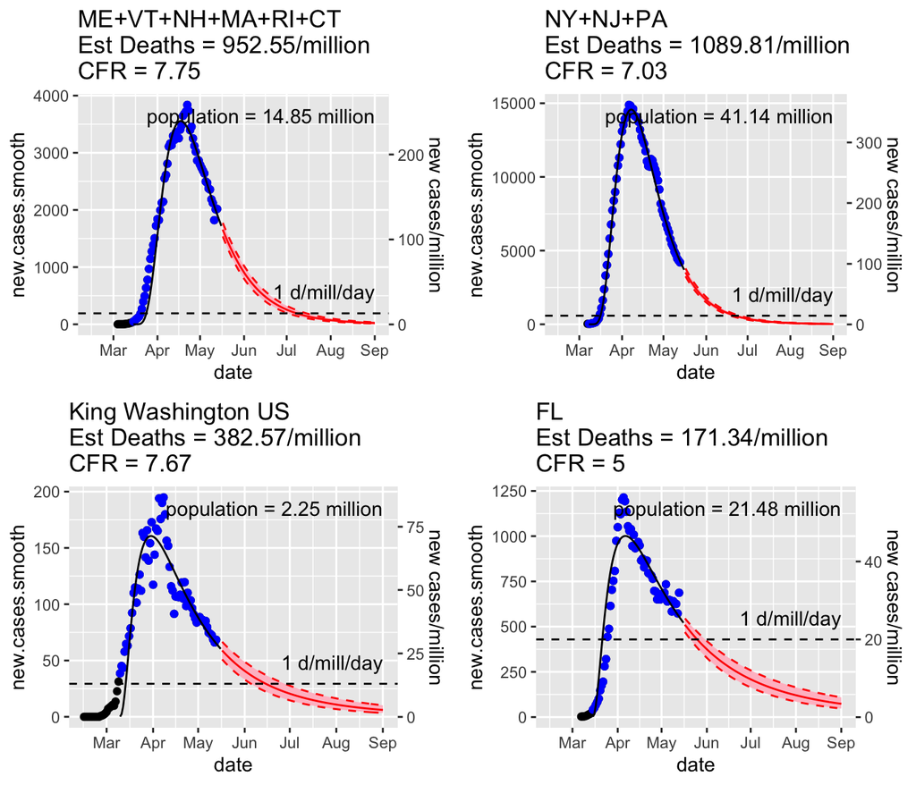

Across the US, the new case curves (7-day average) show a peak about a week ago. It is entirely possible that this is a bump and new cases will start back up. We have definitely seen that happen a few times.

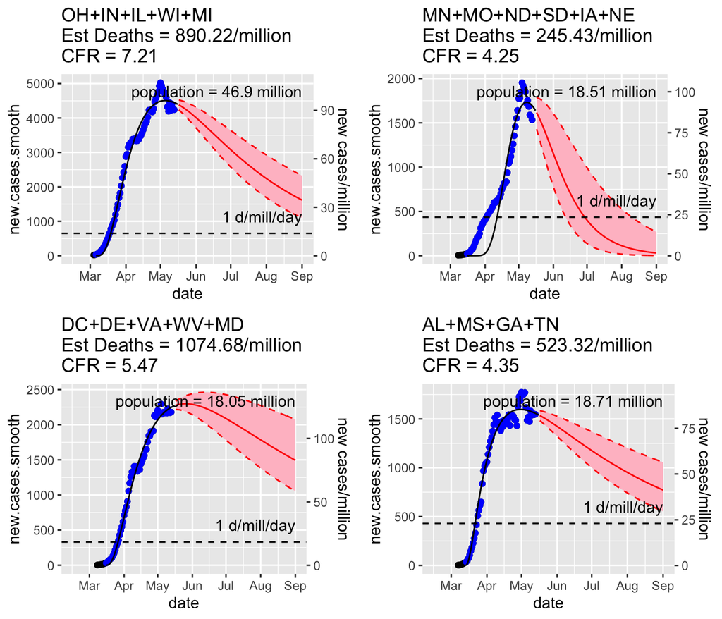

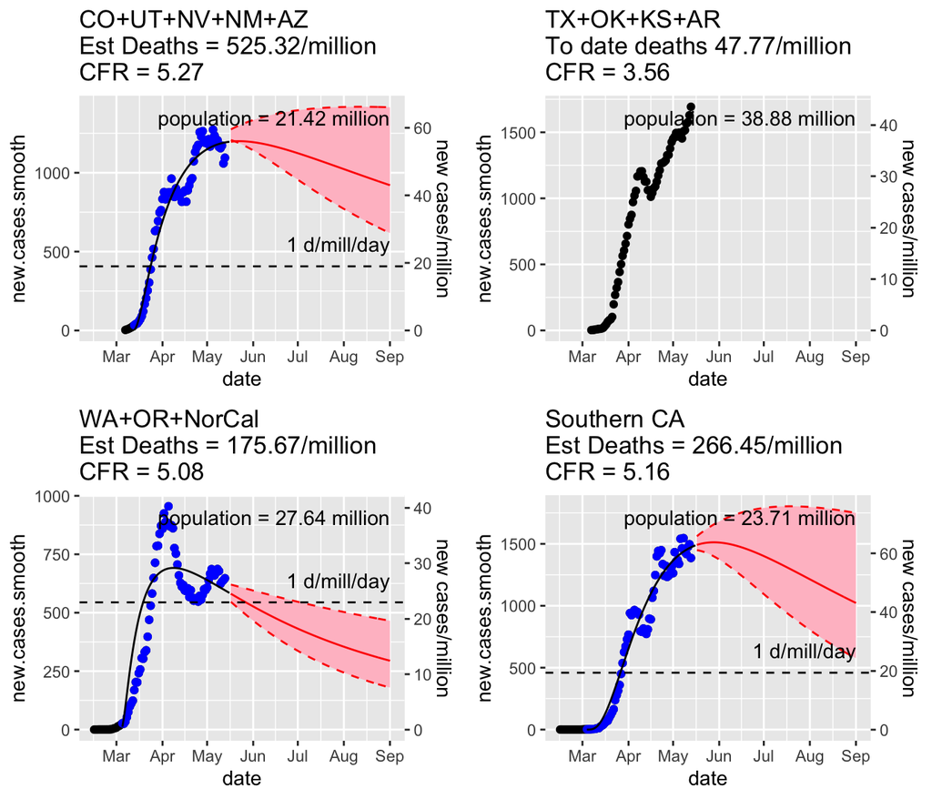

## Summary

Overall, it still looks like the first wave will last well into summer for most of the US (excluding part of the NE) but new cases per million is staying relatively low.